# Kelompok 2_Project Kapita Selekta

## **PROYEK TUGAS AKHIR KAPITA SELEKTA FISIKA KOMPUTASI**

### **Simulasi Generator Termoelektrik Sederhana Berbahan Ni-Cu Dengan Metode Beda Hingga**

Copyright © 2022 Muhammad Ridho Pratama

### **A. LATAR BELAKANG**

Aktivitas manusia dalam kehidupan sehari-hari tidak terlepas dari kebutuhan akan energi listrik. Hal ini memicu semakin maraknya pengembangan energi alternatif sebagai pembangkit energi listrik seperti energi angin, sel matahari (solar cell), OTEC (Ocean Thermal Energy Conversion), panas bumi dan lain sebagainya (Busthomy, 2020). Namun dibalik pengembangan energi alternatif tersebut, perlu diperhatikan pula pengembangan mengenai penghematan energi atau konservasi energi. Hal ini dikarenakan dengan menghemat energi maka secara tidak langsung juga akan meningkatkan efisiensi termal suatu sistem energi yang dapat memperpanjang masa habisnya persediaan tenaga energi tersebut.

Sekitar dua pertiga energi hilang dalam bentuk limbah panas yang dibuang dari cooling towers saat membangkitkan energi listrik di pembangkit listrik. Alasan utamanya adalah sistem turbin bertenaga gas atau uap yang beroperasi untuk menghasilkan sebagian besar tenaga listrik bekerja dengan cara membakar bahan bakar yang menghasilkan energi dalam bentuk panas. Dimana energi panas tersebut akan dikonversi menjadi energi mekanik dalam turbin dan kemudian akan diubah menjadi energi listrik dalam generator. Hal ini mengakibatkan hanya satu pertiga energi yang dilepaskan dari bahan bakar yang dimanfaatkan sebagai energi listrik dalam generator (Jouhara, et. al., 2021). Sehingga hal tersebut mendorong para peneliti dan industri untuk meningkatkan efisiensi sistem energi. Hal ini ditandai dengan meningkatnya minat dalam pengembangan generator termoelektrik. Saat ini, generator termoelektrik dapat memberi kemungkinan untuk memulihkan energi panas yang hilang (Champier, 2017).

Generator termoelektrik merupakan salah satu alternatif dalam kebutuhan energi listrik yang bekerja dengan mengkonversi energi panas menjadi listrik secara langsung atau dengan fungsi sebaliknya yaitu dari listrik yang menghasilkan dingin (Pradana, 2020). Bahan termoelektrik bekerja tanpa menghasilkan gas beracun karbon dioksida maupun polutan lain seperti logam berat. Generator termoelektrik paling sederhana terdiri dari termokopel yang terdiri dari tipe – n (bahan dengan kelebihan elektron) dan tipe – p (bahan dengan kekurangan elektron) elemen yang terhubung listrik secara seri dan panas secara paralel (Yusuf, 2018). Untuk menghasilkan listrik, material termoelektrik cukup diletakkan sedemikian rupa dalam rangkaian material yang berbeda dengan menghubungkan sumber panas dan dingin. Dari rangkaian itu akan dihasilkan sejumlah listrik sesuai dengan jenis bahan yang dipakai dan perbedaan temperatur yang terjadi. Perbedaan temperatur yang terjadi akan berpengaruh terhadap tegangan output generator yang dihasilkan (Salim & Indarto, 2018).

Karakteristik modul termoelektrik ini bergantung pada efek Seebeck, efek Peltier, serta efek Thompson. Berdasarkan efek seebeck, GGL akan timbul dalam suatu rangkaian yang berasal dari dua buah material yang berbeda karena adanya perbedaan temperatur (Haryanto, et. al., 2015). Sedangkan, efek peltier yang merupakan kebalikan dari efek seebeck ini terjadi ketika arus listrik yang melewati persimpangan dua bahan menghasilkan atau menyerap panas per satuan waktu. Efek ini muncul karena energi rata-rata elektron yang terlibat dalam transmisi arus listrik di berbagai konduktor berbeda (Jouhara, et.al., 2021). Dalam termoelektrik dikenal pula koefisien seebeck yang merupakan tegangan buka rangkaian yang dihasilkan antara dua titik pada konduktor ketika perbedaan temperatur seragam sebesar 1 K diterapkan antara dua titik tersebut (Zega, 2021). Efek termoelektrik telah banyak ditemukan dalam kehidupan diantaranya dalam bidang bisnis elektronik yaitu jam tangan termoelektrik, kotak pendingin, kotak pemanas dan lain-lain; dalam bidang medis yaitu perangkat biomedis; dan dalam bidang Internet of Things yaitu penghasil energi untuk catu daya, dan masih banyak lagi penerapan dari termoelektrik ini. Pemanfaatan serta pengembangan penelitian efek termoelektrik yang kian meningkat ini menjadi pendorong dalam pengambilan topik termoelektrik sebagai penerapan materi *Partial Differential Equation* (PDE) dalam mata kuliah kapita selekta fisika komputasi, yakni sebaga solusi untuk menemukan hubungan antara tegangan keluaran dengan perubahan temperatur dalam efek termoelektrik.

### **B. RUMUSAN MASALAH**

Berdasarkan latar belakang yang telah dipaparkan, terdapat suatu permasalahan yang akan dibahas dalam proyek ini yaitu mengenai **“Bagaimana hubungan antara tegangan keluaran terhadap perubahan (gradien) temperatur dalam efek termoelektrik yang dihasilkan oleh bahan material Ni-Cu Serta Pola Distribusi Difusi Panasnya?”** Dalam proses penyelesaian, akan digunakan persamaan konduksi panas yang merupakan salah satu persamaan dalam Partial Differential Equation (PDE). Hubungan antara $V_{out}$ dan $\Delta T$ tersebut akan ditentukan berdasarkan persamaan tegangan keluaran dalam efek termoelektrik sebagai berikut:

$V_{out} = (\alpha_P -\alpha_N)(T_h - T_c)$

$\frac{\partial T}{\partial t} = k' \frac{\partial^{2} T}{\partial x^{2}}\ $

Adapun untuk nilai variabel koefisien seebeck ($\alpha$) pada bahan Ni-Cu diambil dari jurnal yang berjudul “*Review of Micro Thermoelectric Generator*” (Yan, et. al., 2018).

Berikut adalah ilustrasi generator termoelektrik

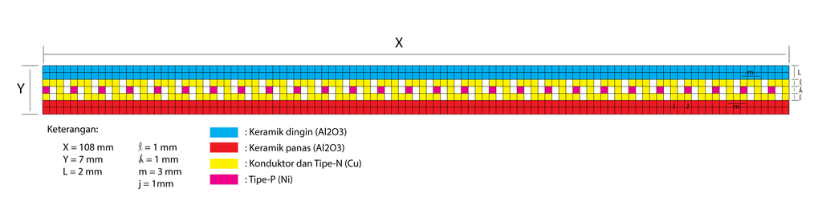

Note:

Bagian yang berwarna putih pada sebelah pasangan N-Type dan P-Type merupakan ruang kosong yang diasumsikan diisi udara

### **C. METODE PENYELESAIAN**

Metode penyelesaian yang digunakan dalam permasalahan ini yaitu metode *Finite Difference* atau metode beda hingga yang merupakan salah satu metode penyelesaian dari *Partial Differential Equation* (PDE). Berikut persamaan yang digunakan

$ \frac{\partial T}{\partial t} =k \frac{\partial^{2} T}{\partial x^{2}} $

Maka:

##### $\frac{\partial^{2} T}{\partial x^{2}} = \frac{T^{l}_{i+1, j} - 2T^{l}_{i, j} + T^{l}_{i-1, j}}{\triangle x^2}$

$\frac{\partial^{2} T}{\partial y^{2}} = \frac{T^{l}_{i,j+1} - 2T^{l}_{i, j} + T^{l}_{i, j-1}}{\triangle y^2}$

$\frac{\partial T}{\partial t} = \frac{T^{l+1}_{i, j} - T^{l}_{i, j}}{\triangle t}$

##### $T^{l+1}_{i,j} = T^{l}_{i,j} + \frac{k'\triangle t}{\triangle s^2}(T^{l}_{i+1, j} + T^{l}_{i-1, j} - 4T^{l}_{i, j} + T^{l}_{i, j+1} + T^{l}_{i, j-1})$

##### Syarat Batas

##### untuk i = 0

##### $T^{l+1}_{i,j} = T^{l}_{i,j} + \frac{k'\triangle t}{\triangle s^2}(2T^{l}_{i+1, j} - 4T^{l}_{i, j} + T^{l}_{i, j+1} + T^{l}_{i, j-1})$

##### untuk i tepi

##### $T^{l+1}_{i,j} = T^{l}_{i,j} + \frac{k'\triangle t}{\triangle s^2}(2T^{l}_{i-1, j} - 4T^{l}_{i, j} + T^{l}_{i, j+1} + T^{l}_{i, j-1})$

Note:

Pada bagian-bagian yang berbatasan dengan udara dapat dihitung secara mirroring.

Serta dengan $\frac{k'\triangle t}{\triangle s^2} = \lambda$

Adapun untuk nilai variabel koefisien seebeck $\alpha$ pada bahan nikel dan tembaga diambil dari jurnal yang berjudul “Review of Micro Thermoelectric Generator” (Yan, et. al., 2018). Dan setiap bahan material memiliki difusivitasnya berbeda.

### **D. HASIL PEMROSESAN**

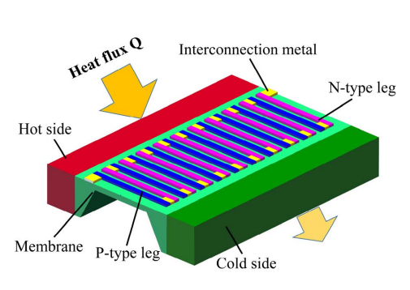

```python
import numpy as np
import matplotlib.pyplot as plt
from numba import jit
```

### Difusivitas Bahan

#### 1. $\alpha_{Al_{2}O_{3}} = 12 {mm}^{2}/s$

#### 2. $\alpha_{Ni} = 23 {mm}^{2}/s$

#### 3. $\alpha_{Cu} = 100 {mm}^{2}/s$

```python
# Variabel

ds = 1      # jarak antar node
dt = 0.001  # diskritisasi waktu (sekon)

X = 108     # 108 mm = 10.8 cm  (panjang peltier)
Y = 7       # 7 mm (lebar peltier)
t = 300     # 300 detik = 5 menit

# Difusivitas Termal Bahan
kk = 12; kNi = 23; kCu = 100; kU = 0.13
```

### Inisialisasi Temperature Luar

### Temperature untuk Percobaan 1

```python
Th = np.array([120]*X)  # Suhu Panas
Tc = np.array([0]*X)    # Suhu dingin

# Inisialisasi Permukaan Bahan (F (Field) = Bidang)
F = np.zeros((Y+2, X), dtype = np.float64)
F[0] = Th
F[-1] = Tc
```

```python
# Inisialisasi Permukaan Bahan Untuk Tiap Frame Waktu
T = np.array([F for i in range(int(t/dt)+1)], dtype = np.float64)
```

### Fungsi Finite Difference Untuk Bidang Peltier

```python
@jit(nopython = True)
def FDM(T, t, dt, k_k, k_cu, k_ni, ds):
    for time in range(int(t/dt)): #untuk t harus ditambah 1
        for j in range(np.shape(T)[1]-2): #untuk j harus ditambah 1
            for i in range(np.shape(T)[2]):


                if 1<=(j+1)<3 : # bagian keramik atas
                    lamda = ((k_k*dt)/(ds**2))
                    if (j+1) == 1:
                        if i == 0:
                            T[time+1][j+1][i] =  T[time][j+1][i] + lamda*(2*T[time][j+1][i+1] - 4*T[time][j+1][i] + T[time][j+2][i] + T[time][j][i])
                        if i == len(T[0][0])-1:
                            T[time+1][j+1][i] =  T[time][j+1][i] + lamda*(2*T[time][j+1][i-1] - 4*T[time][j+1][i] + T[time][j+2][i] + T[time][j][i])
                        if 0<i<len(T[0][0])-1:
                            T[time+1][j+1][i] =  T[time][j+1][i] + lamda*(T[time][j+1][i+1] + T[time][j+1][i-1] - 4*T[time][j+1][i] + T[time][j+2][i] + T[time][j][i])
                    else :
                        if (i+1)%4 == 0: # bagian bawah keramik udara
                            T[time+1][j+1][i] =  T[time][j+1][i] + lamda*(T[time][j+1][i+1] + T[time][j+1][i-1] - 4*T[time][j+1][i] + 2*T[time][j][i])
                        else :
                            if i == 0:
                                T[time+1][j+1][i] =  T[time][j+1][i] + lamda*(2*T[time][j+1][i+1] - 4*T[time][j+1][i] + T[time][j+2][i] + T[time][j][i])
                            if i == len(T[0][0])-1:
                                T[time+1][j+1][i] =  T[time][j+1][i] + lamda*(2*T[time][j+1][i-1] - 4*T[time][j+1][i] + T[time][j+2][i] + T[time][j][i])
                            if 0<i<len(T[0][0])-1:
                                T[time+1][j+1][i] =  T[time][j+1][i] + lamda*(T[time][j+1][i+1] + T[time][j+1][i-1] - 4*T[time][j+1][i] + T[time][j+2][i] + T[time][j][i])


                if (j+1)==3: # bagian konduktor panas
                    lamda = ((k_cu*dt)/(ds**2))
                    if (i+1)%4 == 0: # ruang kosong
                        #T[time+1][j+1][i] = 0
                        pass
                    else :
                        if (i+1)%4==0 or (i-1)%4==0: # bagian tengah bawahnya udara
                            T[time+1][j+1][i] =  T[time][j+1][i] + lamda*(T[time][j+1][i+1] + T[time][j+1][i-1] - 4*T[time][j+1][i] + 2*T[time][j][i])

                        else : # bagian pinggir
                            if (i+2)%4==0: # ini batas depan
                                T[time+1][j+1][i] =  T[time][j+1][i] + lamda*(2*T[time][j+1][i-1] - 4*T[time][j+1][i] + T[time][j+2][i] + T[time][j][i])
                            if (i%4)==0: # ini batas belakang
                                T[time+1][j+1][i] =  T[time][j+1][i] + lamda*(2*T[time][j+1][i+1] - 4*T[time][j+1][i] + T[time][j+2][i] + T[time][j][i])


                if (j+1)==4: # bagian junction
                    if (i%4)==0: # bagian Ni
                        lamda = ((k_ni*dt)/(ds**2))
                        T[time+1][j+1][i] =  T[time][j+1][i] + lamda*(- 4*T[time][j+1][i] + 2*T[time][j+2][i] + 2*T[time][j][i])

                    if (i-1)%2!=0: # bagian Cu
                        lamda = ((k_cu*dt)/(ds**2))
                        T[time+1][j+1][i] =  T[time][j+1][i] + lamda*(- 4*T[time][j+1][i] + 2*T[time][j+2][i] + 2*T[time][j][i])

                    else : # bagian kosong
                        #T[time+1][j+1][i] = 0
                        pass


                if (j+1)==5: # bagian konduktor dingin
                    lamda = ((k_cu*dt)/(ds**2))
                    if ((i+1)%4 != 0) and ((i+1)%4==0 or (i-1)%4==0): # daerah kosong
                        pass

                    else :
                        if i%4 == 0: # batas depan
                            T[time+1][j+1][i] =  T[time][j+1][i] + lamda*(2*T[time][j+1][i-1] - 4*T[time][j+1][i] + T[time][j+2][i] + T[time][j][i])
                        if (i)%2 != 0: # bagian tengah atasnya udara
                            T[time+1][j+1][i] =  T[time][j+1][i] + lamda*(T[time][j+1][i+1] + T[time][j+1][i-1] - 4*T[time][j+1][i] + 2*T[time][j+2][i])
                        if (i%4 != 0) and ((i)%2 == 0): # batas belakang
                            T[time+1][j+1][i] =  T[time][j+1][i] + lamda*(2*T[time][j+1][i+1] - 4*T[time][j+1][i] + T[time][j+2][i] + T[time][j][i])



                if 6<=(j+1)<8:
                    lamda = ((k_k*dt)/(ds**2))
                    if (j+1) == 6:
                        if ((i+1)%4 != 0) and ((i+1)%4==0 or (i-1)%4==0): # bagian keramik dingin dengan atasnya udara
                            T[time+1][j+1][i] =  T[time][j+1][i] + lamda*(T[time][j+1][i+1] + T[time][j+1][i-1] - 4*T[time][j+1][i] + 2*T[time][j+2][i])
                        else: # bagian keramik dingin dengan atasnya konduktor dingin
                            if i == 0:
                                T[time+1][j+1][i] =  T[time][j+1][i] + lamda*(2*T[time][j+1][i+1] - 4*T[time][j+1][i] + T[time][j+2][i] + T[time][j][i])
                            if i == len(T[0][0])-1:
                                T[time+1][j+1][i] =  T[time][j+1][i] + lamda*(2*T[time][j+1][i-1] - 4*T[time][j+1][i] + T[time][j+2][i] + T[time][j][i])
                            if 0<i<len(T[0][0])-1:
                                T[time+1][j+1][i] =  T[time][j+1][i] + lamda*(T[time][j+1][i+1] + T[time][j+1][i-1] - 4*T[time][j+1][i] + T[time][j+2][i] + T[time][j][i])

                    else:
                        if i == 0:
                            T[time+1][j+1][i] =  T[time][j+1][i] + lamda*(2*T[time][j+1][i+1] - 4*T[time][j+1][i] + T[time][j+2][i] + T[time][j][i])
                        if i == len(T[0][0])-1:
                            T[time+1][j+1][i] =  T[time][j+1][i] + lamda*(2*T[time][j+1][i-1] - 4*T[time][j+1][i] + T[time][j+2][i] + T[time][j][i])
                        if 0<i<len(T[0][0])-1:
                            T[time+1][j+1][i] =  T[time][j+1][i] + lamda*(T[time][j+1][i+1] + T[time][j+1][i-1] - 4*T[time][j+1][i] + T[time][j+2][i] + T[time][j][i])

                #print(T[time+1][j+1])
    #print(lamda)
    return T

Temp = FDM(T, t, dt, kk, kCu, kNi, ds)
```

```python
s = np.arange(0,10.8,0.1)
print(len(s))
```

```
108
```

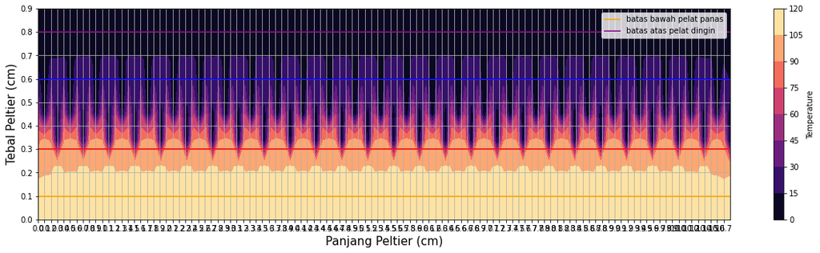

```python
x, y = np.meshgrid(np.linspace(0, X/10,X), np.linspace(0, Y/10+0.2, Y+2))
plt.figure(figsize=(20,5))
plt.axhline(y = 0.3, color = 'red', linestyle = '-')
plt.axhline(y = 0.6, color = 'blue', linestyle = '-' )
plt.axhline(y = 0.1, color = 'orange', linestyle = '-', label = 'batas bawah pelat panas' )
plt.axhline(y = 0.8, color = 'purple', linestyle = '-', label = 'batas atas pelat dingin')
plt.contourf(x, y, Temp[300000], cmap = 'magma')
plt.xlabel('Panjang Peltier (cm)', fontsize = 15)
plt.ylabel('Tebal Peltier (cm)', fontsize = 15)
#plt.xticks(np.arange(0, 10.8,0.1))
plt.legend(loc = 1)
#plt.grid()
plt.colorbar(label = "Temperature")
```

### Efek Seebeck

##### $$Vout = (\alpha_p - \alpha_n) \times \sum^{N}_{i}(T_{h} - T_{c})$$

##### > Nikel (Ni)

##### $\alpha_p = 21.3 \frac{\mu V}{K}$

##### > Tembaga (Cu)

##### $\alpha_n = 20.6 \frac{\mu V}{K}$

```python
@jit(nopython = True)

def efek_seebeck(data, a_P, a_N):
    hot_j = 3
    cold_j = 5
    V = []
    for time in range(len(data)-1):
        dT = []
        for i in range(len(Temp[0][0])):
            if (i%4)==0:
                dT.append(data[time+1][3][i]-data[time+1][5][i])
        V.append((a_P-a_N)*(sum(dT)))
    return V
```

```python
Vout = efek_seebeck(Temp, 21.3, 20.6)
Vs = np.array(Vout)
Vs = Vs*(10**-3)
time = np.linspace(0, t, len(Vout))
print('Tegangan Output saat (t=300 detik) = ', Vs[-1], 'volt')
```

```
Tegangan Output saat (t=300 detik) =  1.0961002294885032 volt
```

```python
def v_steady(Vout, waktu, dV, f):
    for i in range(len(Vout)):
        if i == 0:
            deltaV = np.abs(round(Vout[i], f)-0)/round(Vout[i], f)
        if i > 0:
            deltaV = np.abs(round(Vout[i], f)-(round(Vout[i-1], f)))/round(Vout[i], f)
        t = waktu[i]
        Vs = Vout[i]
        if deltaV <= dV:
            break
    return t, Vs
```

```python
SS_pos = v_steady(Vs, time, 0.0001, 5)
print("Detik ke =", SS_pos[0], "Tegangan = ", SS_pos[1])
```

```
Detik ke = 0.6730022433408112 Tegangan =  1.0802043048120442
```

```python
Vmax = np.max(Vs)
indeks = np.where(Vs == Vmax)
t_max = time[indeks[0][0]]

print('Tegangan Maksimum = ', Vmax, "Pada waktu ke = ", t_max)
print('indeks vmax =', indeks[0][0])
```

```
Tegangan Maksimum =  1.0961002294885154 Pada waktu ke =  6.401021336737789
indeks vmax = 6401
```

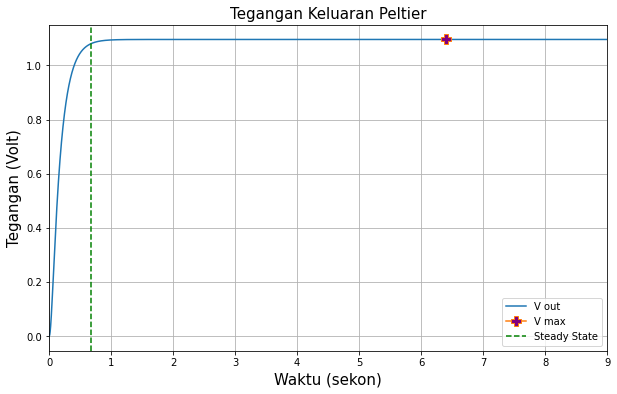

```python
plt.figure(figsize=(10, 6))
plt.plot(time, Vs, label = 'V out')
plt.plot([t_max], [Vmax], marker = "P", markersize=10, markerfacecolor = 'purple', label = 'V max')
plt.xlim([0, 9])
plt.grid(); plt.title("Tegangan Keluaran Peltier", fontsize = 15)
plt.ylabel("Tegangan (Volt)", fontsize = 15);plt.xlabel('Waktu (sekon)', fontsize = 15)
plt.axvline(x=SS_pos[0], color = 'green', linestyle = '--', label = 'Steady State')
plt.legend()
plt.show()
```

# Animasi Simulasi

```python
import numpy as np
import scipy
import matplotlib.pyplot as plt
from scipy import sparse
import timeit

import matplotlib.animation as animation
from matplotlib.animation import FuncAnimation
from IPython import display
```

```python
fig = plt.figure(figsize=(20,4))
#x, y = np.meshgrid(np.linspace(0, X/10, X), np.linspace(0, Y/10+0.2, Y+2))
def data(i):
    peta = Temp[i]
    return peta
def animate(i):
    x, y = np.meshgrid(np.linspace(0, X/10, X), np.linspace(0, Y/10+0.2, Y+2))
    plt.clf()
    plt.xlabel("x(cm)")
    plt.ylabel("y(cm)")
    cont = plt.contourf(x, y, data(i),cmap = 'magma')
    plt.title("Termoelektrik")
anim = animation.FuncAnimation(fig, animate, frames = 1000, repeat=False)
video = anim.to_html5_video()
html = display.HTML(video)
display.display(html)
plt.close()
```

[video not shown]

### **E. ANALISIS**

Peltier merupakan perangkat termoelektrik yang reversibel, perangkat ini mampu menghasilkan panas dan dingin dengan memberikan tegangan pada rangkaian. Meskipun efisiensi untuk peltier terbilang cukup kecil, perangkat ini juga mampu menghasilkan energi listrik dengan memberikan kalor pada satu sisi dan mendinginkan sisi lainnya. Berdasarkan prinsip tersebut, maka dilakukanlah simulasi 2D sederhana untuk modul peltier dengan sel termoelektrik metal berbahan Tembaga(Cu) sebagai N-Type, dan Nikel sebagai P-Type.

Simulasi diawali dengan mencari bahan referensi berupa jurnal yang berjudul “Review of Micro Thermoelectric Generator” mengenai generator mikro termoelektrik. Selanjutnya merancang desain bahan dan variabel-variabel mengenai bahan yang akan disimulasikan. Dari hasil perancangan, dipilihlah 3 bahan untuk masing-masing bagian peltier. Untuk bagian penutup atau luaran peltier, digunakan bahan alumunium oksida (Al2O3), bahan keramik ini juga digunakan pada peltier konvensional sebagai penutup sel termoelektrik. Kemudian untuk sel termoelektrik, dipilih bahan Tembaga sebagai N-Type dan Nikel sebagai P-Type. Kedua bahan ini dipilih berdasarkan salah satu sumber yang membahas mengenai generator mikro termoelektrik.

Berikut adalah variabel - variabel bahan yang dibutuhkan

[figure not shown]

Untuk variabel lain yang merujuk pada dimensi panjang telah diilustrasikan pada gambar di poin sebelumnya.

Pada simulasi ini digunakan metode beda hingga, dengan jarak antar node diasumsikan sebesar 1 mm, dan interval waktu sebesar 0.001 s. Nilai interval waktu yang sangat kecil tersebut dipilih untuk mengakomodir faktor gamma pada metode numerik beda hingga. Sedangkan pemilihan jarak antar partisi sebesar 1 mm ditentukan atas pertimbangan dimensi sel termoelektrik yang kecil. Konsekuensi dari pemilihan nilai-nilai yang kecil ini berdampak pada beban komputasi akibat penggunaan memori yang sangat tinggi. Oleh karenanya variabel waktu dan dimensi peltier yang dipilih telah melalui beberapa percobaan.

Panas mengalir melalui sambungan-sambungan tipe p dan n untuk mencapai sisi lain keramik. Namun pada lapisan sambungan, jenis bahannya telah berbeda dengan faktor difusivitas yang berbeda pula, hal ini menyebabkan aliran panas lebih mudah mengalir pada bahan-bahan dengan difusivitas panas paling besar yakni tembaga kemudian diikuti dengan nikel, hingga pada waktu tertentu mencapai keadaan steady state dengan penyebaran temperatur antara sambungan pada tipe-N (tembaga) sama dengan temperatur di sambungan tipe-P (Nikel).

### **G. REFERENSI**

- Busthomy, P. L., & Widyartono, M. (2020). Generator termoelektrik dengan memanfaatkan panas yang terbuang dari api pembakaran untuk pengisian baterai handphone. Jurnal Teknik Elektro, 9(2).
- Champier, D. (2017). Thermoelectric generators: A review of applications. Energy Conversion and Management, 140, 167-181.
- Chapra, Steven C dan Canale, Raymond P,. (1991). Numerical Methods for Engineers with Personal Computer Applications, MacGraw-Hill Book Company
- Haryanto, H., Makhsum, M. R., & Saraswati, I. (2015). Perancangan Modul Termoelektrik Generator Menggunakan Peltier. Teknika: Jurnal Sains dan Teknologi, 11(1), 26-37.
- Landau, R.H., Paez, M.J., & Bordeianu. (2015). Computational Physics Problem Solving with Python (Third Edition). Germany: Wiley-VCH
- Jouhara, H., Żabnieńska-Góra, A., Khordehgah, N., Doraghi, Q., Ahmad, L., Norman, L., ... & Dai, S. (2021). Thermoelectric generator (TEG) technologies and applications. International Journal of Thermofluids, 9, 100063.
- Pradana, M. A., & Widyartono, M. (2020). Prototipe Pembangkit LIstrik Termoelektrik Generator Menggunakan Penghantar Panas Aluminium, Kuningan Daan seng. Jurnal teknik elektro, 9(2).
- Salim, A. A., & Indarto, B. (2018). Studi Eksperimental Karakterisasi Elemen Termoelektrik Peltier Tipe TEC. JEECAE (Journal of Electrical, Electronics, Control, and Automotive Engineering), 3(1), 179-182.
- Yan, J., Liao, X., Yan, D., & Chen, Y. (2018). Review of micro thermoelectric generator. Journal of Microelectromechanical Systems, 27(1), 1-18.
- Yusuf, M. (2018). Unjuk Kinerja Pembangkit Energi Elektrik Memanfaatkan Limbah Panas Mesin Mobil City Car Menggunakan Modul Termo Electric Cooler (TEC). Prosiding Semnastek.
- Zega, B. O. (2021). Analisa Pengaruh Jumlah Dan Susunan Termoelektrik Generator Terhadap Karakteristik Termoelektrik Generator Pada Motor Bensin 4 Cylinder (Doctoral dissertation, Universitas Islam Riau).